# AllLife Bank Customer Segmentation

### Context

AllLife Bank wants to focus on its credit card customer base in the next financial year. They have been advised by their marketing research team, that the penetration in the market can be improved. Based on this input, the Marketing team proposes to run personalized campaigns to target new customers as well as upsell to existing customers. Another insight from the market research was that the customers perceive the support services of the back poorly. Based on this, the Operations team wants to upgrade the service delivery model, to ensure that customer queries are resolved faster. Head of Marketing and Head of Delivery both decide to reach out to the Data Science team for help

### My Objective

To identify different market segments in the existing customer base, using their spending patterns as well as past interaction with the bank, using clustering algorithms, and provide recommendations to the bank on how to better market to and service these customers.

### Data Description

The data provided is of various customers of a bank and their financial attributes like credit limit, the total number of credit cards the customer has, and different channels through which customers have contacted the bank for any queries (including visiting the bank, online and through a call center).

## Data Dictionary

- Sl_No: Primary key of the records
- Customer Key: Customer identification number
- Average Credit Limit: Average credit limit of each customer for all credit cards
- Total credit cards: Total number of credit cards possessed by the customer
- Total visits bank: Total number of visits that customer made (yearly) personally to the bank
- Total visits online: Total number of visits or online logins made by the customer (yearly)
- Total calls made: Total number of calls made by the customer to the bank or its customer service department (yearly)

# Import Libraries

```python
import numpy as np
import pandas as pd
```

```python
import matplotlib.pyplot as plt
%matplotlib inline
import seaborn as sns
```

```python
pd.set_option('display.max_columns', None)
pd.set_option('display.max_rows', 200)
```

```python
from sklearn.preprocessing import StandardScaler
from scipy.spatial.distance import pdist
from sklearn.cluster import AgglomerativeClustering
from scipy.cluster.hierarchy import dendrogram, linkage, cophenet
from sklearn.decomposition import PCA

import warnings
warnings.filterwarnings("ignore")
```

```python
from sklearn.model_selection import train_test_split
from sklearn.cluster import KMeans
from sklearn.metrics import silhouette_score
from scipy.spatial.distance import cdist
from yellowbrick.cluster import KElbowVisualizer, SilhouetteVisualizer
import sklearn.metrics
```

```python
from google.colab import drive
drive.mount('/content/drive')
```

### Import Data

```python
data = pd.read_excel('/content/drive/MyDrive/Python Course/Credit_Card_Customer_Data.xlsx')
```

```python
data.shape
```

```
(660, 7)
```

- There are 660 rows and 7 columns

```python
df = data.copy()
```

```python
df.head(10)
```

|  | Sl_No | Customer Key | Avg_Credit_Limit | Total_Credit_Cards | Total_visits_bank | Total_visits_online | Total_calls_made |
| --- | --- | --- | --- | --- | --- | --- | --- |
| 0 | 1 | 87073 | 100000 | 2 | 1 | 1 | 0 |
| 1 | 2 | 38414 | 50000 | 3 | 0 | 10 | 9 |
| 2 | 3 | 17341 | 50000 | 7 | 1 | 3 | 4 |
| 3 | 4 | 40496 | 30000 | 5 | 1 | 1 | 4 |
| 4 | 5 | 47437 | 100000 | 6 | 0 | 12 | 3 |
| 5 | 6 | 58634 | 20000 | 3 | 0 | 1 | 8 |
| 6 | 7 | 48370 | 100000 | 5 | 0 | 11 | 2 |
| 7 | 8 | 37376 | 15000 | 3 | 0 | 1 | 1 |
| 8 | 9 | 82490 | 5000 | 2 | 0 | 2 | 2 |
| 9 | 10 | 44770 | 3000 | 4 | 0 | 1 | 7 |

- It looks like both the Sl_no column and the Customer Key are both just identification numbers and therefore we will drop these columns

```python
df.drop(['Sl_No', 'Customer Key'], axis=1, inplace=True)
```

```python
df.shape
```

```
(660, 5)
```

- We now have 5 columns, these will be the ones we use for our model.

```python
df.info()
```

```
<class 'pandas.core.frame.DataFrame'>
RangeIndex: 660 entries, 0 to 659
Data columns (total 5 columns):
 #   Column               Non-Null Count  Dtype
---  ------               --------------  -----
 0   Avg_Credit_Limit     660 non-null    int64
 1   Total_Credit_Cards   660 non-null    int64
 2   Total_visits_bank    660 non-null    int64
 3   Total_visits_online  660 non-null    int64
 4   Total_calls_made     660 non-null    int64
dtypes: int64(5)
memory usage: 25.9 KB
```

- All columns are data type integer
- There are no null values

```python
df.describe().T
```

|  | count | mean | std | min | 25% | 50% | 75% | max |
| --- | --- | --- | --- | --- | --- | --- | --- | --- |
| Avg_Credit_Limit | 660.0 | 34574.242424 | 37625.487804 | 3000.0 | 10000.0 | 18000.0 | 48000.0 | 200000.0 |
| Total_Credit_Cards | 660.0 | 4.706061 | 2.167835 | 1.0 | 3.0 | 5.0 | 6.0 | 10.0 |
| Total_visits_bank | 660.0 | 2.403030 | 1.631813 | 0.0 | 1.0 | 2.0 | 4.0 | 5.0 |
| Total_visits_online | 660.0 | 2.606061 | 2.935724 | 0.0 | 1.0 | 2.0 | 4.0 | 15.0 |
| Total_calls_made | 660.0 | 3.583333 | 2.865317 | 0.0 | 1.0 | 3.0 | 5.0 | 10.0 |

- It looks as though customers have an average of almost 5 credit cards
- The Avg. credit limit is 34,574 this column has much larger values than the rest. We will definitely need to scale our data.
- Looks like people prefer to call the bank vs. going in person or online. The mean for calls is 3.5 vs. around 2.5 for the others.

```python
# check for missing values
df.isna().sum()
```

```
Avg_Credit_Limit       0
Total_Credit_Cards     0
Total_visits_bank      0
Total_visits_online    0
Total_calls_made       0
dtype: int64
```

- There are no na or null values in the data set

```python
df.duplicated().sum()
```

```
11
```

- It looks like there are 11 duplicate values in our dataset.
- We should treat these before moving forward with our EDA.

```python
# Taking a look at our duplicate entries
duplicate = df[df.duplicated(keep=False)].sort_values('Avg_Credit_Limit')
duplicate.head(22)
```

|  | Avg_Credit_Limit | Total_Credit_Cards | Total_visits_bank | Total_visits_online | Total_calls_made |
| --- | --- | --- | --- | --- | --- |
| 310 | 5000 | 4 | 5 | 0 | 1 |
| 395 | 5000 | 4 | 5 | 0 | 1 |
| 56 | 6000 | 1 | 0 | 2 | 5 |
| 175 | 6000 | 1 | 0 | 2 | 5 |
| 385 | 8000 | 7 | 4 | 2 | 0 |
| 334 | 8000 | 7 | 4 | 2 | 0 |
| 17 | 8000 | 2 | 0 | 3 | 4 |
| 215 | 8000 | 4 | 0 | 4 | 7 |
| 162 | 8000 | 2 | 0 | 3 | 4 |
| 29 | 8000 | 4 | 0 | 4 | 7 |
| 252 | 9000 | 4 | 5 | 0 | 4 |
| 324 | 9000 | 4 | 5 | 0 | 4 |
| 257 | 10000 | 6 | 4 | 2 | 3 |
| 295 | 10000 | 6 | 4 | 2 | 3 |
| 320 | 12000 | 6 | 5 | 2 | 1 |
| 378 | 12000 | 6 | 5 | 2 | 1 |
| 361 | 18000 | 6 | 3 | 1 | 4 |
| 250 | 18000 | 6 | 3 | 1 | 4 |
| 425 | 47000 | 6 | 2 | 0 | 4 |
| 455 | 47000 | 6 | 2 | 0 | 4 |
| 464 | 52000 | 4 | 2 | 1 | 2 |
| 497 | 52000 | 4 | 2 | 1 | 2 |

- Here we can see all of our duplicate values.
- Now it is possible that these are all different customers just with the exact same values across all 5 categories.
- This is an instance where the serial number and customer ID could be useful.
- Thankfully we still have our copy of the original dataset so that we can check this before dropping any of these duplicates.

```python
# checking original dataset to verify duplicate values
data.duplicated().sum()
```

```
0
```

- Good thing we decided to check before dropping any of these duplicates, or else we would have been removing valid data points from our dataset.

# EDA

### Univariate Analysis

- Let's first look at histograms and boxplots for each variable in our data set

```python
# create function for histogram and boxplot grouped together
def hist_box(data, feature, figsize=(12, 7), kde=False, bins=None):
    """
    data: df
    feature: df column
    figsize: (figsize=(12,7))
    kde: show density curve (False)
    bins: bins for histogram (None)
    """

    f2, (ax_box2, ax_hist2) = plt.subplots(
        nrows=2,
        sharex=True,
        gridspec_kw={'height_ratios': (0.25, 0.75)},
        figsize=figsize
    )
    sns.boxplot(data=data, x=feature, ax=ax_box2, showmeans=True, color='yellow'
    )
    sns.histplot(data=data, x=feature, ax=ax_hist2,kde=kde, bins=bins, palette='winter'
    ) if bins else sns.histplot(
        data=data, x=feature, ax=ax_hist2, kde=kde
    )
    ax_hist2.axvline(
        data[feature].mean(), color='red', linestyle='--'
    )
    ax_hist2.axvline(
        data[feature].median(), color='black', linestyle='-'
    )
```

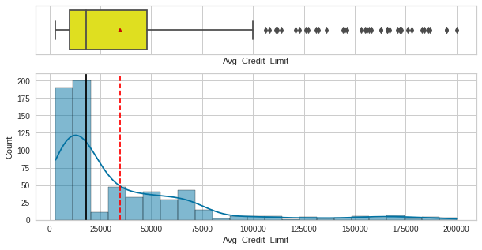

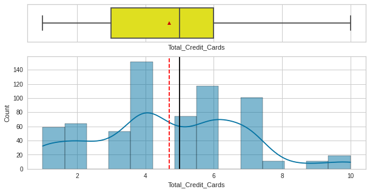

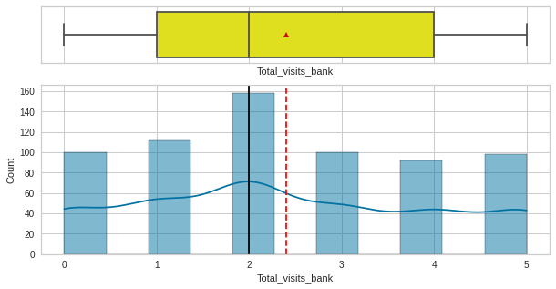

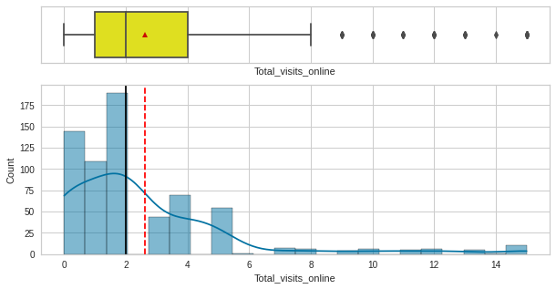

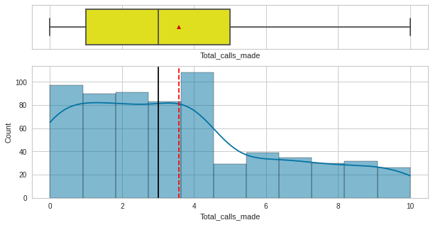

```python
cols=df.columns

for item in cols:
    hist_box(df, item, kde=True, figsize=(10, 5))
```

- Avg. credit limit and total visits online are both very right skewed with many outliers. We will keep these outliers as they are real and important data points for the business.
- There aren't any outliers for the other variables.
- All variables seem to have a right skew to varying degrees, total visits to the bank is closet to a normal distribution.

# Bivariate Analysis

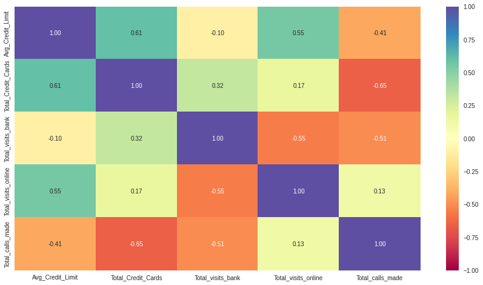

```python
# creating a heatmap to check for correlations
plt.figure(figsize=(15,8))
sns.heatmap(df.corr(), annot=True, vmin=-1, vmax=1, fmt='.2f', cmap='Spectral');
```

- no extreme correlation, the highest is 0.61 between Avg. Credit Limit and Total Credit Cards, which makes sense, more cards more limit.
- There is a negative correlation of -0.65 between Total Calls Made and Total Credit Cards.

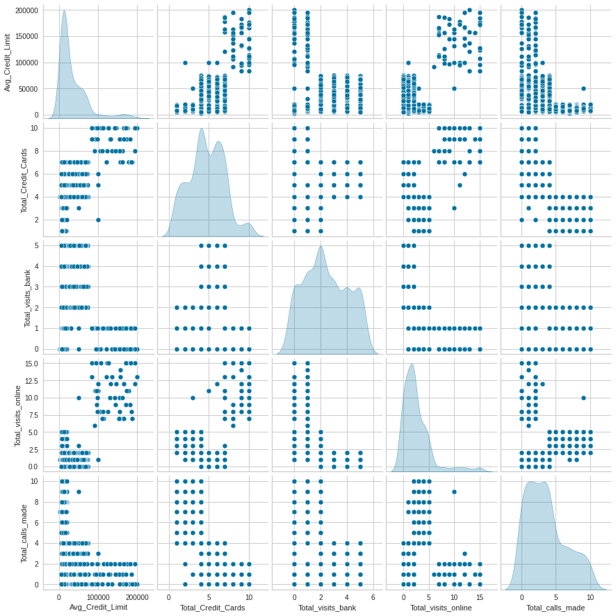

```python
sns.pairplot(data=df, diag_kind='kde')
```

- We can already see where some pairs have what look like distinct groupings.
- We will seee if clustering gives us similar groups.

# Scaling and Clustering

```python
# scaling the data before we start clustering
scale = StandardScaler()
subset = df.copy()
subset_scaled = scale.fit_transform(subset)
```

Let's create a data frame for our scaled data

```python
df_subset_scaled = pd.DataFrame(subset_scaled, columns=subset.columns)
```

Now we can use the Elbow Method to see what is the best number of clusters.

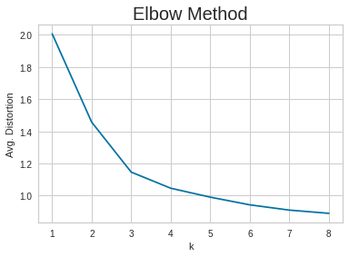

```python
clusters = range(1, 9)
meanDistortions = []

for k in clusters:
    model = KMeans(n_clusters=k)
    model.fit(df_subset_scaled)
    prediction = model.predict(df_subset_scaled)
    meanDistortions.append(sum(np.min(cdist(
        df_subset_scaled, model.cluster_centers_, "euclidean"), axis=1))
        / df_subset_scaled.shape[0])

plt.plot(clusters, meanDistortions, "bx-")
plt.xlabel("k")
plt.ylabel("Avg. Distortion")
plt.title("Elbow Method", fontsize=20)
```

- It seems to me that there is a pretty clear elbow at 3, so I'm going to use 3 as my cluster value.

Now let's see if we get a similar result from looking at the silhouette scores

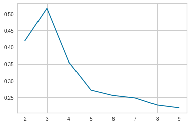

```python
sil_score = []
cluster_list = list(range(2,10))

for n_clusters in cluster_list:
    cluster_method = KMeans(n_clusters=n_clusters)
    preds = cluster_method.fit_predict((df_subset_scaled))
    score = silhouette_score(df_subset_scaled, preds)
    sil_score.append(score)

plt.plot(cluster_list, sil_score)
```

- Very noticeable peak right at 3 so this backs our findings from the elbow method.
- But even though 3 seems like our number, let's still check it out by using the Silhouette Visualizeer.

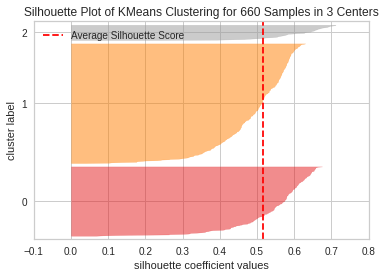

```python
# checking our silhouette coefficient of 3
visualizer = SilhouetteVisualizer(KMeans(3, random_state=1))
visualizer.fit(df_subset_scaled)
visualizer.show()
```

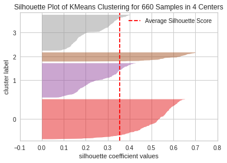

```python
visualizer = SilhouetteVisualizer(KMeans(4, random_state=1))
visualizer.fit(df_subset_scaled)
visualizer.show()
```

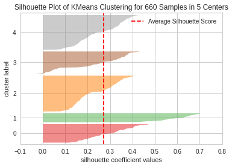

```python
visualizer = SilhouetteVisualizer(KMeans(5, random_state=1))
visualizer.fit(df_subset_scaled)
visualizer.show()
```

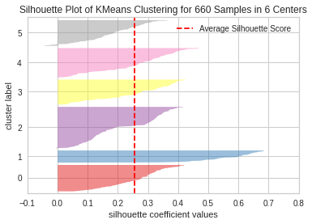

```python
visualizer = SilhouetteVisualizer(KMeans(6, random_state=1))
visualizer.fit(df_subset_scaled)
visualizer.show()
```

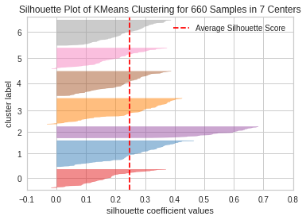

```python
visualizer = SilhouetteVisualizer(KMeans(7, random_state=1))
visualizer.fit(df_subset_scaled)
visualizer.show()
```

- I tried looking at 4 through 7 as well, just to compare.
- 5 and 7 don't look too bad for cluster values based on the visualizer
- So we may want to test out 5 or 7 in addition to 3.

### So sticking with 3 as our cluster value let's see how it performs

```python
kmeans = KMeans(n_clusters=3, random_state=1)
kmeans.fit(df_subset_scaled)
```

```
KMeans(n_clusters=3, random_state=1)
```

```python
# Now we want to add a column for kmeans labels in our original df
df['Kmeans_Segments'] = kmeans.labels_
```

```python
cluster_profile = df.groupby('Kmeans_Segments').mean()
```

```python
cluster_profile['Count_in_Segments'] = (
    df.groupby('Kmeans_Segments')['Total_Credit_Cards'].count().values
)
```

```python
# view cluster profile
cluster_profile.style.highlight_max(color='lightgreen', axis=0)
```

[output not shown]

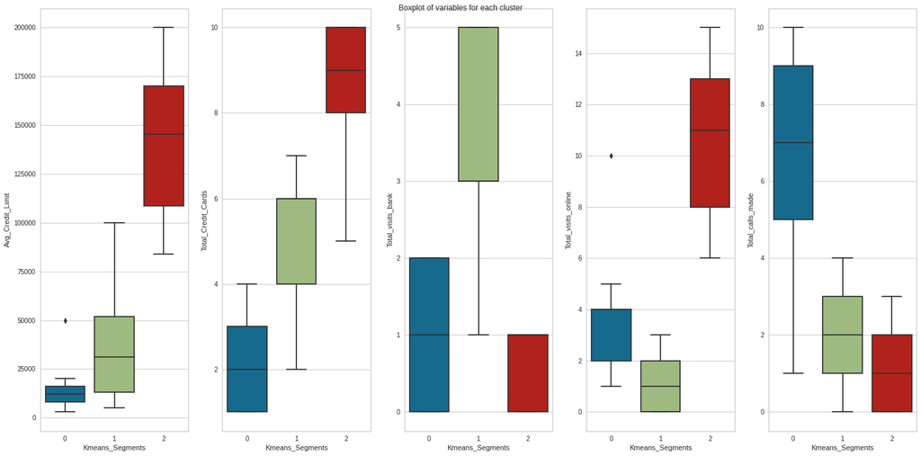

```python
fig, axes = plt.subplots(1, 5, figsize=(20, 10))
fig.suptitle('Boxplot of variables for each cluster')
counter=0
for ii in range(5):
    sns.boxplot(ax=axes[ii], y=df[cols[counter]], x=df['Kmeans_Segments'])
    counter = counter + 1

fig.tight_layout(pad=2.0)
```

# Insights

### Cluster 0

- Customers in this cluster are on the lower end as far as their credit card limit and total amount of credit cards.
- While some may visit the bank once or twice the majority prefer to call the bank.
- Most of these customers call the bank an average of 5 to 9 times.
- It's possible the high call volume is because of the customer service which is viewd poorly. Perhaps promoting coming in person or going online may be a better option for good customer service.
- For now though thses customers with 1-3 cards have the most room to expand as customers and it seems calling might be the best way to sell to them.

### Cluster 1

- These customers have a higher credit limit and 4-6 cards on average.
- In person is definitely their choice for contacting the bank with an average customer in this cluster visiting 3-5 times.
- They have the lowest online visits of all the clusters and thier call volume is not substantial.
- I would reccomend selling more to these customers when they come by to visit in person.

### Cluster2

- Most customers in this clusters have a higher average credit limit then the other 2 clusters combined.
- They have an average amount of 8-10 credit cards.
- These are the customers who visit online and they do so more than the other 2 clusters combined.
- However, they have the lowest amount of vists in person and calls.
- I would definitely make sure to reach these customers online.

# Now we are going to try some hierarchical clustering to see if we similar results.

### Checking Linkage with Euclidean distance

```python
# list of different linkage methods we are going to check
# We will use the euclidean dist. metric with each method
linkage_methods = ["single", "complete", "average", "centroid", "ward", "weighted"]

for lm in linkage_methods:
    z = linkage(df_subset_scaled, metric='euclidean', method=lm)
    c, coph_dists = cophenet(z, pdist(df_subset_scaled))
    print(lm, c)
```

```
single 0.7391220243806552
complete 0.8599730607972423
average 0.8977080867389372
centroid 0.8939385846326323
ward 0.7415156284827493
weighted 0.8861746814895477
```

- It looks like the average linkage method has the highest cophenetic correlation when using the euclidean distance

## Now let's try some different distance metrics

### Chebyshev distance

```python
# checking linkages with chebyshev
linkage_methods = ["single", "complete", "average", "weighted"]

for lm in linkage_methods:
    z = linkage(df_subset_scaled, metric='chebyshev', method=lm)
    c, coph_dists = cophenet(z, pdist(df_subset_scaled))
    print(lm, c)
```

```
single 0.7382354769296767
complete 0.8533474836336782
average 0.8974159511838106
weighted 0.8913624010768603
```

- average linkage method is the higheset cophenetic correlation here as well.

### mahalanobis distance

```python
# using mahalanobis metric
linkage_methods = ["single", "complete", "average", "weighted"]

for lm in linkage_methods:
    z = linkage(df_subset_scaled, metric='mahalanobis', method=lm)
    c, coph_dists = cophenet(z, pdist(df_subset_scaled))
    print(lm, c)
```

```
single 0.7058064784553605
complete 0.6663534463875359
average 0.8326994115042136
weighted 0.7805990615142518
```

- average linkage method has the highest correlation when mahalanobis distance

### cityblock distance

```python
# checking linkage with cityblock
linkage_methods = ["single", "complete", "average", "weighted"]

for lm in linkage_methods:
    z = linkage(df_subset_scaled, metric='cityblock', method=lm)
    c, coph_dists = cophenet(z, pdist(df_subset_scaled))
    print(lm, c)
```

```
single 0.7252379350252723
complete 0.8731477899179829
average 0.896329431104133
weighted 0.8825520731498188
```

- average is once again the top performer.
- I think we will go with the average linkage method but let's see which measure of distance performed best with average linkage.

```python
dist_metrics = ["euclidean", "chebyshev", "mahalanobis", "cityblock"]

for dm in dist_metrics:
    z = linkage(df_subset_scaled, metric=dm, method='average')
    c, coph_dists = cophenet(z, pdist(df_subset_scaled))
    print(dm, c)
```

```
euclidean 0.8977080867389372
chebyshev 0.8974159511838106
mahalanobis 0.8326994115042136
cityblock 0.896329431104133
```

- euclidean, chebyshev, and cityblock were all very close but euclidean has the highest cophenetic correlation when it comes to the average linkage method.

# Dendrograms

- We have chosen euclidean as our distance method, and we already know average is max, but it still helps to visualize all of the linkage methods to compare.
- We can do this with Dendrograms.

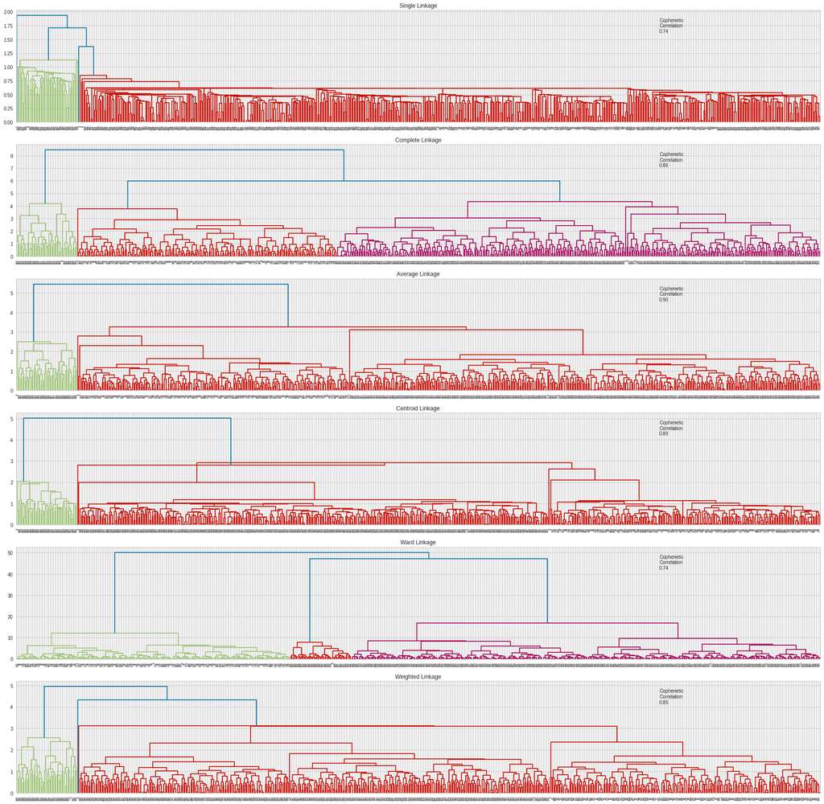

```python
# creating a dendrogram for each linkage method
linkage_methods = ["single", "complete", "average", "centroid", "ward", "weighted"]

# lists for cophenetic correlation
comp_lists = ["Linkage", "Cophenetic Coefficient"]

# create the subplot
fig, axs = plt.subplots(len(linkage_methods), 1, figsize=(30, 30))

# enumerate through the linkage_methods to
# plot their dendrograms and find Cophenetic Correlations
for i, method in enumerate(linkage_methods):
    z = linkage(df_subset_scaled, metric='euclidean', method=method)

    # labeling dendrograms by linkage method
    dendrogram(z, ax=axs[i])
    axs[i].set_title(f'{method.capitalize()} Linkage')

    # annotating cophenetic correltation
    co_corr, co_dist = cophenet(z, pdist(df_subset_scaled))

    axs[i].annotate(
        f'Cophenetic\nCorrelation\n{co_corr:0.2f}', (0.80, 0.80), xycoords='axes fraction'
    )
```

### Observations

- Average linkage is not the most well defined visually, compared to Ward or Weighted linkage, yet it does have the highest cophentic correlation value.
- So we will stick with the average linkage method for our model.
- The Dendrogram does not give us a precise value for the amount of clusters to use, but based on what we have above, 6 looks like a good cluster value, so we will try it out.

```python
HCmodel = AgglomerativeClustering(n_clusters=6, affinity='euclidean', linkage='average')
HCmodel.fit(df_subset_scaled)
```

```
AgglomerativeClustering(linkage='average', n_clusters=6)
```

```python
df_subset_scaled['HC_Clusters'] = HCmodel.labels_
df['HC_Clusters'] = HCmodel.labels_
```

# Cluster Profiling

```python
cluster_profile = df.groupby('HC_Clusters').mean()
```

```python
cluster_profile['count_in_each_segment'] = (
    df.groupby('HC_Clusters')['Total_Credit_Cards'].count().values
)
```

```python
for cl in df["HC_Clusters"].unique():
    print("In cluster {}, The number of credit cards is:".format(cl))
    print(df[df["HC_Clusters"] == cl]["Total_Credit_Cards"].unique())
    print()
```

```
In cluster 3, The number of credit cards is:
[2]

In cluster 4, The number of credit cards is:
[3]

In cluster 2, The number of credit cards is:
[7 5 4 6]

In cluster 5, The number of credit cards is:
[6 5]

In cluster 1, The number of credit cards is:
[3 2 4 1]

In cluster 0, The number of credit cards is:
[ 9  8 10  7]
```

- It looks like our clusters have some overlap in the total amount of credit cards custumers own.
- Also we have some clusters with only 1 value while others have 4, so our cluster may vary in size.
- Let's still proceed with 6 clusters and see how it turns out.

```python
# display cluster profile
cluster_profile.style.highlight_max(color='lightgreen', axis=0)
```

| HC_Clusters | Avg_Credit_Limit | Total_Credit_Cards | Total_visits_bank | Total_visits_online | Total_calls_made | Kmeans_Segments | count_in_each_segment |
| --- | --- | --- | --- | --- | --- | --- | --- |
| 0 | 142750.000000 | 8.875000 | 0.625000 | 10.875000 | 1.020833 | 2.000000 | 48 |
| 1 | 12027.027027 | 2.400901 | 0.932432 | 3.531532 | 6.873874 | 0.000000 | 222 |
| 2 | 33541.450777 | 5.520725 | 3.492228 | 0.984456 | 2.010363 | 0.997409 | 386 |
| 3 | 100000.000000 | 2.000000 | 1.000000 | 1.000000 | 0.000000 | 1.000000 | 1 |
| 4 | 50000.000000 | 3.000000 | 0.000000 | 10.000000 | 9.000000 | 0.000000 | 1 |
| 5 | 100000.000000 | 5.500000 | 0.000000 | 11.500000 | 2.500000 | 2.000000 | 2 |

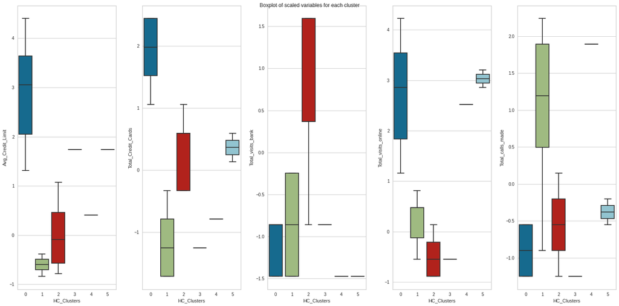

```python
fig, axes = plt.subplots(1, 5, figsize=(20, 10))
fig.suptitle('Boxplot of scaled variables for each cluster')
counter=0
for ii in range(5):
    sns.boxplot(ax=axes[ii], y=df_subset_scaled[cols[counter]], x=df_subset_scaled['HC_Clusters'])
    counter = counter + 1

fig.tight_layout(pad=2.0)
```

[figure not shown]

```python
fig, axes = plt.subplots(1, 5, figsize=(20, 10))
fig.suptitle('Boxplot of scaled variables for each cluster')
counter=0
for ii in range(5):
    sns.boxplot(ax=axes[ii], y=df[cols[counter]], x=df['HC_Clusters'])
    counter = counter + 1

fig.tight_layout(pad=2.0)
```

# Observationns

- Clusteer 0, 1, and 2 account for most of the data, so we will focus on those clusters.

### Cluster 1

- Are your lower end costomers, which means they have the most potential when it comes to sales growth.
- They typically have average credit limits less than 25000 dollars.
- They have between 1-4 credit cards but most have 3 or less.
- They may come in person to visit once or twice go online between 2-4 times, but they will call anywhere from 1-10 times, with the majority of them calling between 5-9 times.
- Reaching them with a phone campaign is probably your best bet

### Cluster 2

- Are your mid range customers. They have an average credit limit anywhere from anywhere 10,000-75,000 dollars but most have less than $50,000 so there is room to grow here within their established range.
- They mostly have between 4-6 credit cards but some may have 7 cards.
- They like to visit the bank in person, making anywhere from 1-5 visits, but it's typically more than 3 visits.
- They have the lowest online visits at 0-3, most 2 or less.
- Their call numbers are 0-4 with 1-3 being the most common.
- I would definitley reccomend trying to reach these customers in person when they come visit the bank.

# Dimensionality Reduction using PCA for visualization

we can use this method to reduce our dimensions down to 2, so we can visualize our clusters better and see how they are separated.

```python
# we want to have 2 components
pca = PCA(n_components=2)

# transform data and create DataFrame
X_reduce_pca = pca.fit_transform(df_subset_scaled)
df_reduce_pca = pd.DataFrame(
    data=X_reduce_pca, columns=['component 1', 'component 2']
)
```

```python
# Check variance explained
pca.explained_variance_ratio_.sum()
```

```
0.8203149671899145
```

- Our 2 principal components explain 82.03% of the variance in the data.

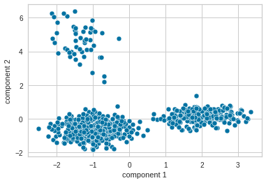

```python
# plot it out to better visualize
sns.scatterplot(data=df_reduce_pca, x='component 1', y='component 2')
```

- We can see our 3 clusters here, but the one in the top left is not nearly as compact as the other 2 clusters.

We can colorize the different cclusters based on their label to better see which one each represents.

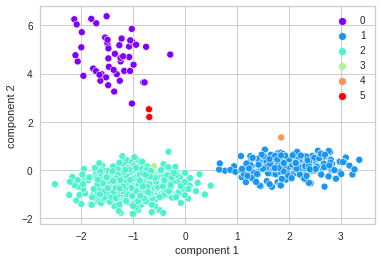

```python
sns.scatterplot(
    data=df_reduce_pca,
    x='component 1',
    y='component 2',
    hue=df['HC_Clusters'],
    palette='rainbow'
)

plt.legend(bbox_to_anchor=(1,1))
```

- Clusters 0, 1, and 2 are the primary clusters while clusters 3-5 are mostly outliers.

# Insights

- Despite using 2 different clustering methods and a different number of clusters with each one, we still came up with similar results.
- Both methods showed that 3 clusters represent the majority of the data.
- The appearance of these 3 clusters in both methods giving us similar results just reinforces our findings.
- These main 3 clusters split the data neatly into 3 market segmenatations.
- There is lower end segment in which the customers have an avg. of less than 25k, with primarily between 1-3 credit cards and their prefered method to reach the bank is by calling.
- There is a mid market segment of customers who have an avg. credit limit of anywhere between 10k-75k, yet most have less than 50k. Most in this segment have 4-6 cards and prefer coming in person with many coming 3-5 times to visit the bank in person.
- The 3rd segment is your top level credit card customers who have an avg. credit limit from 75k-200k, with most having over 100,000k. These customers tend to have 8-10 credit cards and do most of their bank visits online.

# Business Reccomendations

- I would reccomend that AllLife bank's marketing team look at splitting their customer base into 3 segements for the upcoming financial year.
- These segments could be thought of as low, medium, and high, and these segments would be based on a customers avg. credit limit as well as the number of credit cards they have.
- For the Operations team I have also included reccomendations for each market segment based on their primary mode of contact. Naturally Customer service perception should be improved acoss the board but being able to specialize certain help and needs by segment will hopefully make for better training and interactions with customers.

### Segment 1 (low)

- Your low end market segment may want to be a prime focus as it has the most room to grow. The customers in the low end segment tend to prefer calling the bank as their method of contact. Given this information a targeted phone campaign may be the best way to sell more credit cards in this market segment.
- As for improving the customer service perception in this segment, perhaps the Operations team could work with the local banks to call periodically and check up on clients. Just a call to see if they might need any assitance with their accounts, or other banking problems they might be able to help with. Then have an automated satisfaction survey after the call to better improve customer service over the phone in this segment.

### Seegment 2 (medium)

- The medium customer segment has already shown that they have some decent business with the bank. They are mostly below 50k but upwards of 75k for some so there is a wide range of growth to be had in this segment.
- These medium segment customers have between 4-6 cards for the most part and they like to visit the bank in person.
- A great way to reach them may be through marketing materials and promotional items placed in the banks primarilly aimed at this medium market segment advertising to them how they can grow their potential with the bank even further. Bank tellers and associates may even want to offer to setup meetings with a banker for these in person visiters.
- For Operations to improve customer service perception in this segment they wwould need to make sure banks are trained how to establish a welcoming and professional lobby, teach staff how to respond to customers and best practices for handling and defusing in person complaints.

### Segment 3 (High)

- The 3rd segment consists of your top level credit card customers. These are the customers have over many have over 100k as their average credit limit and some have as high as 200k credit limits.
- These customers have between 8-10 credit cards and they prefer banking online as their form of visiting the bank.
- With online being their preference I would reccomend possibly doing a targeted email marketing campaign as well as maybe some special offer notifications to their online banking account. It might be hard to sell more credit cards to these customers as they already have 8-10, so I would put less sales resources into this segment and instead focus more on customer service.
- Operations needs to make online customer service whether through email, and automated, or live chat abilities on the website. These are your high level clients. They are going to expect a certain level of service and you want to provide that as one of them leaving will be more detrimental than the lower sales numbers for this segment.
- You may be able to continue selling more credit cards in this high market segment, but perhaps offering some other products or services here might help as well. Offering things like balance transfers or promotional points if they switch over to a new card.

These would be my reccomendations to AllLife Bank based on my findings through k-clustering and hierarchical clustering.

```python
!jupyter nbconvert --to html /content/Jonathan_Hutcheson_AllLife_Bank.ipynb
```

```
[NbConvertApp] Converting notebook /content/Jonathan_Hutcheson_AllLife_Bank.ipynb to html
[NbConvertApp] Writing 1403361 bytes to /content/Jonathan_Hutcheson_AllLife_Bank.html
```